# ST661: Assignment 3

NISHANT KUMAR

08 November, 2019

#### Question 1

Type in library(ggplot2) library(MASS) head(Pima.tr) This code loads the data set Pima.tr, and its help file. Use ggplot2 for all plots. Using this dataset: a.Make a scatterplot plot of bp versus npreg.

```r
library(ggplot2)
library(MASS)
head(Pima.tr)
```

```
##   npreg glu bp skin  bmi   ped age type
## 1     5  86 68   28 30.2 0.364  24   No
## 2     7 195 70   33 25.1 0.163  55  Yes
## 3     5  77 82   41 35.8 0.156  35   No
## 4     0 165 76   43 47.9 0.259  26   No
## 5     0 107 60   25 26.4 0.133  23   No
## 6     5  97 76   27 35.6 0.378  52  Yes
```

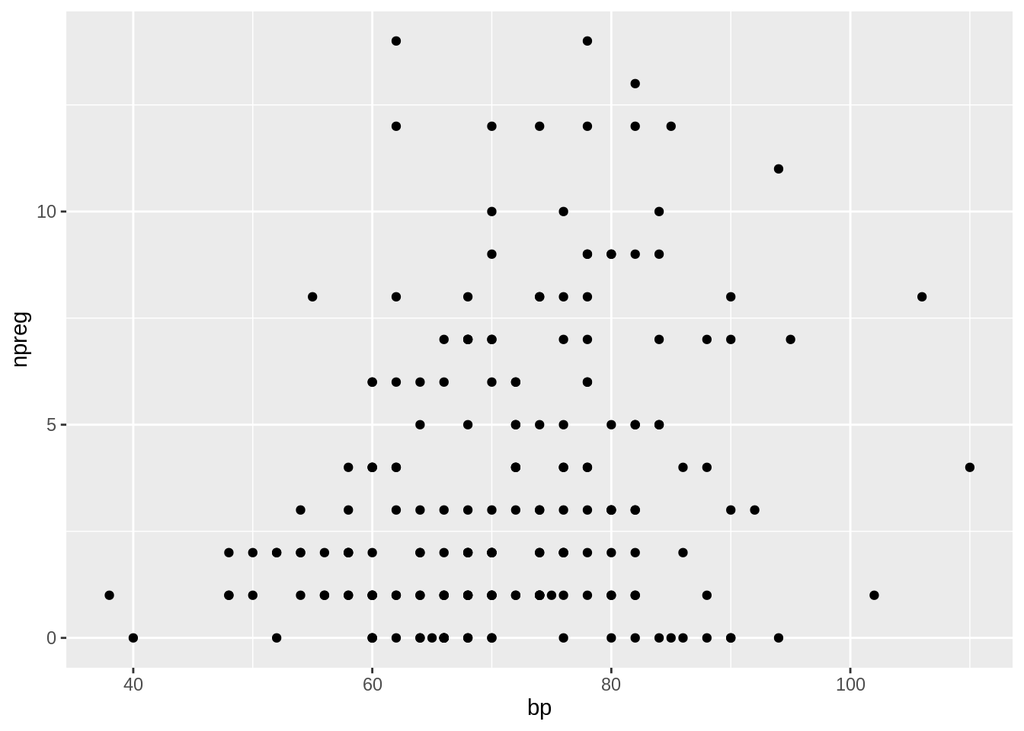

```r
ggplot(data=Pima.tr)+geom_point(mapping=aes(x =bp ,y =npreg))
```

b.Using the function cut_interval, construct a factor version of npreg with n=4 levels. Call this new variable npregf. Add this variable to dataset Pima.tr.

```r
npregf<-cut_interval(Pima.tr$npreg,n=4)
npregf
```

```
##   [1] (3.5,7]   (3.5,7]   (3.5,7]   [0,3.5]   [0,3.5]   (3.5,7]   [0,3.5]
##   [8] [0,3.5]   [0,3.5]   [0,3.5]   [0,3.5]   (7,10.5]  [0,3.5]   (10.5,14]
##  [15] [0,3.5]   (3.5,7]   [0,3.5]   (10.5,14] [0,3.5]   [0,3.5]   [0,3.5]
##  [22] [0,3.5]   (3.5,7]   [0,3.5]   [0,3.5]   (7,10.5]  [0,3.5]   [0,3.5]
##  [29] (3.5,7]   [0,3.5]   [0,3.5]   [0,3.5]   [0,3.5]   [0,3.5]   [0,3.5]
##  [36] (10.5,14] [0,3.5]   [0,3.5]   [0,3.5]   [0,3.5]   (7,10.5]  [0,3.5]
##  [43] (3.5,7]   [0,3.5]   [0,3.5]   [0,3.5]   (3.5,7]   [0,3.5]   [0,3.5]
##  [50] [0,3.5]   [0,3.5]   [0,3.5]   (7,10.5]  [0,3.5]   [0,3.5]   (3.5,7]
##  [57] [0,3.5]   [0,3.5]   [0,3.5]   (7,10.5]  (3.5,7]   [0,3.5]   (7,10.5]
##  [64] (3.5,7]   (3.5,7]   (3.5,7]   (3.5,7]   [0,3.5]   [0,3.5]   [0,3.5]
##  [71] (3.5,7]   [0,3.5]   (7,10.5]  [0,3.5]   [0,3.5]   [0,3.5]   [0,3.5]
##  [78] [0,3.5]   [0,3.5]   (10.5,14] [0,3.5]   (3.5,7]   (3.5,7]   (7,10.5]
##  [85] [0,3.5]   [0,3.5]   [0,3.5]   (3.5,7]   [0,3.5]   [0,3.5]   [0,3.5]
##  [92] (3.5,7]   (3.5,7]   [0,3.5]   [0,3.5]   (10.5,14] (3.5,7]   [0,3.5]
##  [99] [0,3.5]   (7,10.5]  [0,3.5]   (3.5,7]   [0,3.5]   [0,3.5]   (3.5,7]
## [106] (3.5,7]   (3.5,7]   [0,3.5]   [0,3.5]   [0,3.5]   (3.5,7]   (3.5,7]
## [113] (3.5,7]   (7,10.5]  [0,3.5]   [0,3.5]   (7,10.5]  (3.5,7]   [0,3.5]
## [120] (7,10.5]  [0,3.5]   [0,3.5]   (10.5,14] [0,3.5]   (3.5,7]   [0,3.5]
## [127] [0,3.5]   [0,3.5]   [0,3.5]   (3.5,7]   [0,3.5]   (3.5,7]   (3.5,7]
## [134] [0,3.5]   [0,3.5]   [0,3.5]   (3.5,7]   [0,3.5]   [0,3.5]   [0,3.5]
## [141] [0,3.5]   [0,3.5]   [0,3.5]   [0,3.5]   [0,3.5]   (3.5,7]   [0,3.5]
## [148] [0,3.5]   [0,3.5]   (7,10.5]  (10.5,14] (7,10.5]  [0,3.5]   [0,3.5]
## [155] (3.5,7]   (3.5,7]   [0,3.5]   [0,3.5]   (7,10.5]  [0,3.5]   [0,3.5]
## [162] [0,3.5]   [0,3.5]   (3.5,7]   [0,3.5]   (3.5,7]   [0,3.5]   (3.5,7]
## [169] [0,3.5]   [0,3.5]   (3.5,7]   (3.5,7]   (3.5,7]   (3.5,7]   [0,3.5]
## [176] (3.5,7]   [0,3.5]   (3.5,7]   (7,10.5]  [0,3.5]   [0,3.5]   (10.5,14]
## [183] [0,3.5]   (7,10.5]  (7,10.5]  [0,3.5]   (10.5,14] (10.5,14] [0,3.5]
## [190] [0,3.5]   [0,3.5]   (3.5,7]   [0,3.5]   [0,3.5]   [0,3.5]   [0,3.5]
## [197] (3.5,7]   [0,3.5]   [0,3.5]   (7,10.5]
## Levels: [0,3.5] (3.5,7] (7,10.5] (10.5,14]
```

```r
Pima.tr<-data.frame(Pima.tr,npregf)
Pima.tr
```

```
##     npreg glu  bp skin  bmi   ped age type    npregf
## 1       5  86  68   28 30.2 0.364  24   No   (3.5,7]
## 2       7 195  70   33 25.1 0.163  55  Yes   (3.5,7]
## 3       5  77  82   41 35.8 0.156  35   No   (3.5,7]
## 4       0 165  76   43 47.9 0.259  26   No   [0,3.5]
## 5       0 107  60   25 26.4 0.133  23   No   [0,3.5]
## 6       5  97  76   27 35.6 0.378  52  Yes   (3.5,7]
## 7       3  83  58   31 34.3 0.336  25   No   [0,3.5]
## 8       1 193  50   16 25.9 0.655  24   No   [0,3.5]
## 9       3 142  80   15 32.4 0.200  63   No   [0,3.5]
## 10      2 128  78   37 43.3 1.224  31  Yes   [0,3.5]
## 11      0 137  40   35 43.1 2.288  33  Yes   [0,3.5]
## 12      9 154  78   30 30.9 0.164  45   No  (7,10.5]
## 13      1 189  60   23 30.1 0.398  59  Yes   [0,3.5]
## 14     12  92  62    7 27.6 0.926  44  Yes (10.5,14]
```

[output cut: 186 more lines]

c.Plot boxplots of bp for each npregf level.

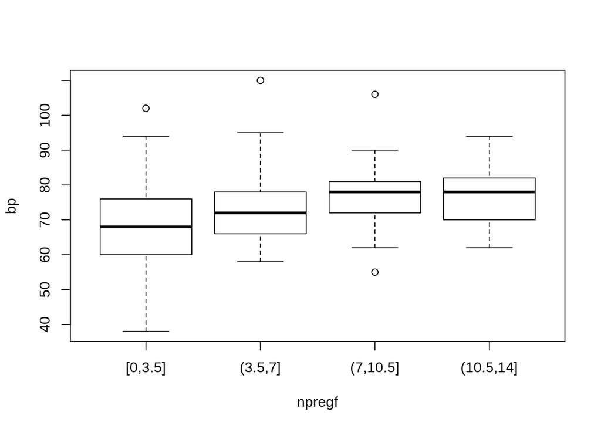

```r
boxplot(bp~npregf,data=Pima.tr)
```

d.Make a scatterplot of glu versus age. Use colour to show variable type and add smooths for the two groups.

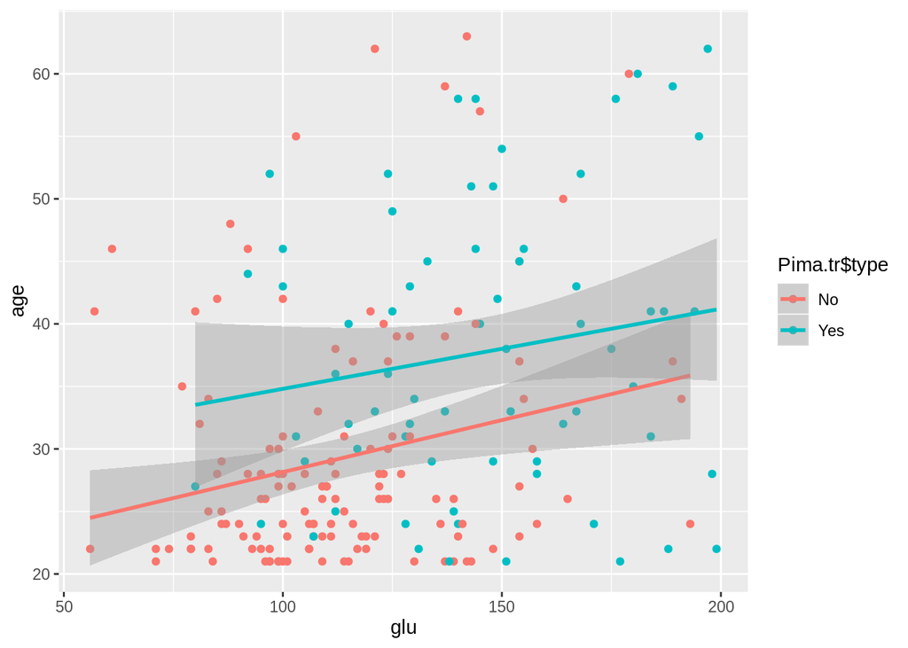

```r
p2<-ggplot(Pima.tr,aes(glu,age,colour=Pima.tr$type))+geom_point()
p2 + stat_smooth(method = "lm", formula = y ~ x, size = 1)
```

e.Redo the previous plot, separating out the two types. (Colour is not now needed)

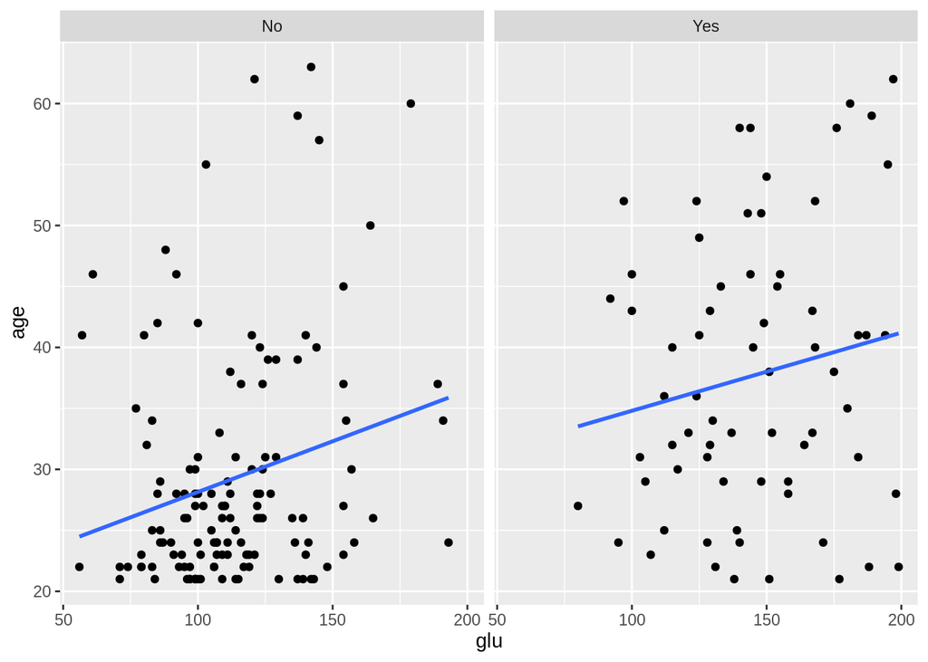

```r
p3<-ggplot(Pima.tr,aes(glu,age))+geom_point()
p3 + stat_smooth(method = "lm", formula = y ~ x,se=FALSE)+facet_grid(~Pima.tr$type)
```

#### Question 2

#### Question 3

The data Hep2012.csv contains data with the points athletes received from each event in the Heptathlon in the 2012 Olympics. Access the data with hep <- read.csv(“Hep2012.csv”) a.Use na.omit to leave out athletes with NAs as they did not complete the event.

```r
hep <- read.csv("Hep2012.csv")
a1<-data.frame(na.omit(hep))
a1
```

```
##                         Athlete X100m.Hurdles X200m X800m High.Jump
## 2               BROERSEN Nadine          1030   875   865      1054
## 3              CHERNOVA Tatyana          1053  1013   971       978
## 4                  COWLEY Sarah           985   833   837       978
## 5                   DADIC Ivona           898   953   880       978
## 6                    DAY Sharon          1040   946   946       941
## 7             DE ANICETO Marisa          1015   863   876       867
## 9                 ENNIS Jessica          1195  1096   984      1054
## 10               FARKAS Gyorgyi           932   822   853       978
## 13                 HAZEL Louise          1053   935   840       724
## 14               IFADIDOU Sofia          1004   805   796       830
## 15              IKAUNIECE Laura          1020   965   934      1016
## 16    JOHNSON-THOMPSON Katarina          1053  1007   954      1093
## 17                KARPOVA Irina           949   849   706       830
## 18             KLUCINOVA Eliska           977   887   878       978
```

[output cut: 51 more lines]

b.Calculate the points total for the athletes and add it as an extra variable to the data frame.

```r
total<-(a1$X100m.Hurdles+a1$X200m+a1$X800m+a1$High.Jump+a1$Javelin+a1$Long.Jump+a1$Shot.Put)
tot1<-cbind(a1,total)
tot1
```

```
##                         Athlete X100m.Hurdles X200m X800m High.Jump
## 2               BROERSEN Nadine          1030   875   865      1054
## 3              CHERNOVA Tatyana          1053  1013   971       978
## 4                  COWLEY Sarah           985   833   837       978
## 5                   DADIC Ivona           898   953   880       978
## 6                    DAY Sharon          1040   946   946       941
## 7             DE ANICETO Marisa          1015   863   876       867
## 9                 ENNIS Jessica          1195  1096   984      1054
## 10               FARKAS Gyorgyi           932   822   853       978
## 13                 HAZEL Louise          1053   935   840       724
## 14               IFADIDOU Sofia          1004   805   796       830
## 15              IKAUNIECE Laura          1020   965   934      1016
## 16    JOHNSON-THOMPSON Katarina          1053  1007   954      1093
## 17                KARPOVA Irina           949   849   706       830
## 18             KLUCINOVA Eliska           977   887   878       978
```

[output cut: 51 more lines]

c.Obtain a vector of the names of the athletes with the best five results overall. Your answer should use two lines of code. Hint: use order.

```r
vc<-(order(-tot1$total))
head(tot1$Athlete[vc],level=c(1:5))
```

```
## [1]   ENNIS Jessica                SCHWARZKOPF Lilli
## [3]   CHERNOVA Tatyana             YOSYPENKO Lyudmyla
## [5]   SKUJYTE Austra               NANA DJIMOU IDA Antoinette
## 38 Levels:   AERTS Sara   BROERSEN Nadine ...   ZELINKA Jessica
```

d.Which three of the 7 events scores are most highly correlated with the overall points total? Answer with one line of code. Hint: use sapply and sort.

```r
names(sort(sapply(tot1[c(-1,-9)], function(x)cor(x,tot1$total)),decreasing = TRUE)[1:3])
```

```
## [1] "Long.Jump"     "X100m.Hurdles" "X800m"
```

#### Question 4